# Chapter 2: Investigating the Memory of Events Using N-Grams, Controlled Vocabulary, and Joins

Computational methods support inquiry into how the discourses and events in the past shape current-day political change. It is common in speeches for political actors to reference the events of the past – whether American politicians reference the Tea Party or British parliamentarians reference the events of the Second World War. Speakers in parliament also acknowledge contemporary public protests as a source of political legitimacy. But the number, intensity, and specific events referenced change over time. What can we learn about how political reforms were made in the past from reviewing how politicians of the past referenced events?

In this chapter, we will explore questions such as these: In the lead-up to the Great Reform Act of 1832, when the middle class got the vote in Britain, which historical references were on the table? Which members of parliament contributed the most to the debate about the Abolition of Slavery in 1833, and of these speakers, whose language reflected the most on the lived experience of toil and cruelty in the system of slavery? Which historical and contemporary events were referenced the most by members of parliament in the era of the Second Reform Act of 1867, when working-class people got the vote for the first time?

This chapter builds upon a sense of how to leverage computational historical thinking to create insight about history. It introduces counting n-grams, or multiword phrases. It also introduces the use of a “controlled vocabulary,” that is, a historian-curated list of important words and phrases, to explore which events were spoken about in parliament during the 1830s.

This chapter builds on the previous to introduce analysts to fundamental data processing techniques in R, commonly used for preparing data for analysis. A key task in data analysis is summarizing a dataset’s characteristics to gain insights into the features of the corpus. Scholars have drawn attention to how th immediacy of computational text analysis–its perceived automation in transforming a raw, messy corpus into a curated object of analysis–masks the degree of transformation that is enacted on the text’s “original” and intermediary data structures (Palermo 2017). In this chapter, we draw attention to each step in data processing, emphasizing how intermediary data wrangling steps contributes to the creation of new knowledge.

One essential concept in data processing is “joining” datasets. A join combines two datasets into one, allowing us to analyze parliamentary texts alongside metadata such as speaker information, dates, and significant events. Additionally, this chapter teaches readers how to work with event-based data, including years, months, and dates. By moving through the data processing steps one-by-one, we draw on Paul Fyfe’s framing of “data mining” as “data archaeology,” shifting attention away from analysis as a final product and instead foregrounding the transformational work of data processing as a central part of the analytical process (Fyfe 2016).

As with the previous chapter, this chapter will emphasize the skills of moving from analyzing text as data to performing a close reading of historical speeches in context. It models the iterative process of working with a controlled vocabulary and reading words in context with the idea of demonstrating a method of inquiry about how and why events happen. The approach we model provides analysts with the tools of deciding for themselves how the patterns identified throughout text mining relate back to their primary sources, that is, the full Hansard debates. As we had previously discussed, our analytic process is iterative, emphasizing that researchers transition from data processing to counting words to applying metrics on those word counts to visualizing trends, and then repeating this deductive process. Throughout the process, it may prove valuable to inspect and re-evaluate the intermediary steps that were taken to arrive at any conclusions about the corpus. This cyclical process may lead to additional historical questions and associations, which may mean more measuring, more visualization, and more guided reading in pursuit of a historical analysis.

## Joining Debate Metadata

We have previously seen how to load the text from a single decade of the Hansard debates. But what should we do if we want to work with not only the text, but also important information like the name of the speaker who gave the speech and the date on which the speech was given?

First we can load the text data from the 1860s speeches, recalling that one of the columns, `sentence_id`, refers to the number of each sentence and its location in the nineteenth-century printed volumes of Hansard’s parliamentary debates, referenced by series (“S”), volume (“V”), and page (“P”). Sentences are listed in the order in which they appeared on the page.

Next, we can load the metadata corresponding with the Hansard debate text.

`hansardr` includes detailed contextual information for each of the speeches, using the same system of references that we saw in the previous data set – series, volume, page, and sentence number. In the `debate_metadata` dataset, however, there is no “text” column, but rather a series of columns that illuminate multiple “fields” of each sentence: the speech date (recorded as “speechdate” within the data) for when the speech was given and the official title of the “debate” in which the sentence was spoken.

In addition to the debate metadata, `hansardr` provides two additional metadata files: `speaker_metadata_1860` and `file_metadata_1860`.

The `speaker_metadata_1860` dataset provides information about the “speaker” of each sentence as the MP’s name was recorded in the original Hansard debates. It also includes a “suggested speaker” column, which contains a disambiguated version of the speaker names where ambiguous or inconsistent references to the same individual have been resolved into a single, standardized name, allowing for more accurate identification of MPs across the corpus.

The “suggested speakers” came from a large-scale disambiguation effort where the authors of this book disambiguated speaker names, building upon the work completed by the Digging into Linked Parliamentary Data Project and the Egger and Spirling database (Eggers and Spirling 2014; Winters and Steer 2013). Our disambiguation effort was designed to address these problems: speakers may have been called only by temporary office titles (like “Prime Minister”); speakers may have been called only by their peerage titles (such as “Duke” or “Viscount”);a single name might have several permutations (such as W. Gladstone, W. E. Gladstone, or William Gladstone all referring to the same Mr. William Ewart Gladstone); speakers may have shared the exact name with someone else who was active during the same period (like the two different Sir Robert Peels in the early 19th-century); speaker names may contain OCR errors; speaker names might have spelling inconsistencies due to how they were originally recorded during the 19th-century; some speakers were misrecorded, such as they were called by the wrong title.

By providing both the original speaker field as well as the disambiguated version, our version of the Hansard dataset preserves the original historical recording and draws attention to the data transformation that occurred in the speaker field before the corpus was packed into `hansardr`. The purpose of including the “suggested speakers” field is to support computational analysis by linking variant or ambiguous names to consistent, canonical speaker identities for a more reliable analysis.

However, we also advise discretion. While disambiguation significantly improves analysis by standardizing speaker identities, it is not without limitations. In some cases, speakers may be incorrectly matched or mislabeled by the algorithm. In others, no suggested speaker name is provided because the necessary metadata was unavailable, and the sheer number of speakers made manual correction infeasible within our project timeline. To address these challenges, we have uploaded the Hansard corpus to Democracy Viewer, an online text mining and data sharing platform where researchers can also submit corrections to the corpus (Buongiorno et al., 2023). Over time, we plan to incorporate data set improvements into future releases of the `hansardr` package.

Additionally, disambiguation can obscure the nuances of the original records, such as shifts in titles or the historical importance of misspellings for understanding contemporary spelling conventions or clerical practices. Due to the historical richness of original speaker names, we provide both the original speaker field and the disambiguated version, so that researchers can critically assess and, if desired, use the original speaker name data instead.

Lastly, `hansardr` provides file metadata. For example, the `file_metadata_1860` dataset provides metadata about the records themselves, including the ID for the original source file, and the column in which the text appears.

We have chosen to store the debate text (`hansard_1860`) separately from the contextual information about each speech (for example, `debate_metadata_1860` or `speaker_metadata_1860`), as well as the information about each hard copy file containing the speeches (`file_metadata_1860`). We subsetted the data into individual files because the data for each decade is quite large. Processing such a large dataset can exceed a computer’s resources, such as its memory. In other cases, we chose to exclude certain fields from processing if they were not immediately relevant to our analysis, as doing so reduces memory usage and improves overall processing speed so that we can focus on our research instead of waiting too long for any intermediary processing step to complete. Furthermore, many operations in this book – for instance, counting words per decade – require just a few datasets loaded at a time.

Many kinds of analyses will require working with multiple datasets from `hansardr` joined together. We will use the function `left_join()` to join the annotated information about speech context with each of the speech text. A left join returns every record from the data frame specified by the left-most argument, and all the matched records from the data frame on the right.

Notice that the resulting dataset, `hansard_corpus_1860`, has information about speaker and date for each sentence of text.

Joins are a crucial concept for combining and analyzing data that is distributed across multiple datasets. They allow us to link related information from different tables based on a shared key or common field thus enabling us to perform analyses of the records in relation to its metadata.

In the example above, both `hansard_1860` and `debate_metadata_1860` share a column called `sentence_id`. The shared `sentence_id` column acts as a common identifier, enabling us to link the speaker and date information from one dataset to the corresponding text of the speech in the other dataset. By using this common identifier, the two datasets can be “joined” together to create a single, unified dataset that we will use for text processing.

Thus joins are so important because it is through linking the records to their metadata that we are able to break text into subsets and analyze change over time, or create a biography of any individual speaker. We can explore the words invoked in parliament in the months leading up to August 15, 1867, when most working-class men in Britain finally achieved the right to vote.

## Multiword Phrases

Beyond analyzing individual words, an analyst may want to explore multiword phrases. Multiword phrases contain formulations of concepts that had powerful political, social, and cultural meaning to speakers, for example, “the will of the people,” a phrase that has been invoked by both radicals and conservatives to support extremely different imaginations of the people. That is, speakers who invoked “the will of the people” might have been bolstering the importance of their speech by gesturing towards their status as a representative of the workers whose labor is the source of all political legitimacy. On the other hand, some speakers might have used the same phrase – “the will of the people” – to kindle an imagination of parliament as a zone a traditional folk whose national identity legitimizes a politics of excluding from citizenship or rights people with certain racial or immigration status. The question becomes: which version of the people was being represented in the discourse in question?

The analyst cannot anticipate in advance how such a phrase might have been used. The only way of gaining knowledge from a count of phrases is to “validate” one theory or the other by gaining more information.

We could, in theory, contrive computational approaches to help us discern why people invoked “the will of the people.” But in *Text Mining for Historical Analysis*, we often want to move from identifying a data-driven phenomenon to gaining more information about historical context by reading the actual speeches. Our approach modeled approach–moving from a visualization overview back to the data itself–provides insight into the rich nuances suggested by speakers by giving us perspective into how they invoke particular phrase in the original records. While visualizations might demonstrate that a parliamentarian invoked a phrase, they may not clearly demonstrate how that phrase was invoked.

Accordingly, in the sections below, we will begin by counting phrases, but that is not where we will end. We will return to the original speeches to read more deeply.

### Finding Bigrams

While there are several approaches to finding multiword phrases, we will demonstrate finding them by tokenizing the text into bigrams.

The following code filters the speeches of the 1860s for the first months of 1867 before the vote on the Second Reform Act, which gave Britain’s urban working-class men the right to vote. We also introduce a new package, `lubridate`, which can be installed in the usual way using `install.packages()`.

Now that we have filtered the dataset for our desired timeline, we can tokenize the text into bigrams. The order in which we perform data processing is important. Tokenizing after filtering ensures that we are working with a smaller and more focused dataset. Working with a smaller dataset ensures we do not exhaust our computer’s resources or its processing capabilities. Skills for handling a large dataset on a smaller computer, like a laptop, is paramount to being able to answer questions while processing large corpora for historical analysis, as we describe in more detail in subsequent chapters.

The order of our steps is not arbitrary, but the outcome of a deliberate decision. We could have reversed them—for example, tokenizing the text before filtering by date. However, that approach would have used more of our computer’s resources, as it would require processing a larger volume of irrelevant text before narrowing the records down to just the data needed for our inquiry into a given time period. With large datasets like Hansard, the sequence of processing steps can significantly impact whether the data remains manageable.

In turn, the limitations of any computing environment directly shape the types of analyses we prioritize. In other words, it is not only theoretical or interpretive concerns that determine our methodological choices, but also what is computationally feasible. Technical constraints become analytical constraints.

When working with large-scale historical data, researchers often adapt their questions, models, and scope to align with the practical boundaries of a computer’s available memory, processing speed, and storage. Computational limitations might encourage researchers to think critically and strategically about what kinds of knowledge are worth pursuing, and how best to pursue them with the tools at hand.

Throughout *Text Mining for Historical Analysis* we have attempted to limit barriers to processing a dataset as large as Hansard through our data organization scheme that breaks each decade of text and related metadata files into their own files, and presents readers with an order of intermediary data processing that is more efficient for working with historical data in R.

The following code uses the `unnest_tokens()` function, which we previously used to split text into individual words. This time, we adjust the function to extract pairs of consecutive words instead. To focus on pairs of consecutive words instead, we set the token argument to n-grams, instructing R to create sequences of consecutive words, and the `n` argument to `2`, specifying that each sequence should consist of two words. The two arguments work together to extract bigrams.

Note that the bigrams extracted overlap, as if the same sentence had been subdivided several times. The presentation of the bigrams is expected, as bigrams are created by looking at each pair of words in order, one step at a time—so each new bigram shares a word with the one before it.

### Counting Bigrams

Now we can count the top bigrams and remove any that contain stop words. We remove stop words to focus on word pairs that might be more meaningful for our analysis.

The above code processes the dataset by applying the following transformations and filters:

`filter(!str_detect(...))` - Removes rows where the `bigram` column contains any stop word. - It constructs a regular expression from a list of stop words (`stop_words$word`) by: - Combining them with the OR operator (`|`). - Surrounding them with word boundaries (`\\b`) to match complete words only. - Only bigrams without stop words are retained.

`filter(str_detect(bigram, "^[a-z]+ [a-z]+$"))` - Keeps rows where the `bigram` column matches a specific pattern: - The `bigram` must consist of exactly two lowercase alphabetic words separated by a single space. - Rows where the `bigram` contains numbers, punctuation, or non-lowercase letters are excluded.

We can now count the resulting bigrams.

We also see a reference to “public meetings.” Why did speakers in parliament invoke public meetings in the lead-up to the Second Reform Act? We will answer this question by reading the original text.

Bigrams, however, have limitations. A bigram only looks at one preceding word, but meaning often depends on words far apart in a sentence. Observing longer utterances—such as by moving beyond bigrams to multiword phrases—allows us to capture linguistic meaning that depends on more distant context than just the immediately preceding word.

### Counting Multiword Phrases

Text mining also allows us to look for multiword phrases beyond bigrams. We can look at 5-word phrases from the year 1867. We can also add a line to filter the n-grams for the presence of the word “people,” looking for voices that refer to democracy, for instance, “the will of the people,” an important concept in the years leading up to 1867, when working-class men in cities got the right to vote for the first time. The results will allow us to ask the question: What are the most frequently-invoked phrases involving “the people”?

We can use a slight adjustment of the code we used above to count bigrams to find n-grams of any length. Here is code for finding common five-word-phrases, filtering them, counting them, and finding the top 50 examples:

|  | ngram | n |
| --- | --- | --- |
| 1 | feelings of the people of | 8 |
| 2 | great body of the people | 32 |
| 3 | great majority of the people | 13 |
| 4 | great mass of the people | 15 |
| 5 | majority of the irish people | 10 |
| 6 | majority of the people of | 27 |

We see a great many political concepts invoked about what members of parliament believed they were working for – the people of Ireland, England, or the metropolis, their representation, condition, education, minds, interests, feelings, rights, and welfare. An entire vocabulary of social engagement and political will was being spelled out.

Reading further down the list of multi-word phrases might give us more hints about the language with which speakers urged the principle of representation. Again, the careful analyst would trace the vocabulary words back to their original context, using the original text of the speeches to develop an argument about why a phrase like “the minds of the people” was used.

When speakers referenced the “minds of the people,” they frequently depicted popular politics as a form of collective political achievement to which ordinary people contributed the rational evidence of their own lived experience. We find the phrase connected to ideas about moral “duty” and political “harmony.” We also see it invoked in reference to Ireland, India and Scotland.

These images of the peoples’ collective wisdom contrast against the bias expressed by elites in another age, which warned against democracy as a form of potential despotism governed by ignorance. It is not surprising that the months leading into the Reform Act of 1867 would see eulogies to the wisdom of popular politics, but the phrase “the minds of the people” offers one entry-point for analysis.

## Using Bigrams to Find Mentions of Events

For many kinds of textual analyses, incorporating external information can help guide the focus of the analysis and ensure it aligns with specific research questions. For example, a historian analyzing data might be interested in tracking references to notable events in British history, such as the Magna Carta, the Spanish Inquisition, or the Glorious Revolution, to see how often these events are mentioned in parliamentary records. To analyze how often these events are mentioned, the analyst may create and use a “controlled vocabulary” which is a predefined list of terms or topics of interest related to the analysis. `hansardr` includes an example controlled vocabulary: a curated list of significant events in British history, along with the corresponding years of their occurrence.

In applying our list, this exercise invites readers to investigate the idea that representations of memory change over time using the controlled vocabulary to search for a set group of phrases. We will use a controlled vocabulary to measure Parliamentarians’ references to past events in the 1860 debates. We are intentionally choosing words such as “riot” or “meeting” that might collect evidence of parliamentary speakers referencing public meetings like those we saw evidence of above. We are also curious about how those references compare with references to famines, wars, strikes, exhibitions, and other contemporary and historical events.

|  | sentence_id | speechdate | debate | year | bigram |
| --- | --- | --- | --- | --- | --- |
| 1 | S3V0185P0_0 | 1867-02-05 | THE QUEEN'S SPEECH. | 1867 | throne adorned |
| 2 | S3V0185P0_0 | 1867-02-05 | THE QUEEN'S SPEECH. | 1867 | regal ornaments |
| 3 | S3V0185P0_1 | 1867-02-05 | THE QUEEN'S SPEECH. | 1867 | robes sitting |
| 4 | S3V0185P0_2 | 1867-02-05 | THE QUEEN'S SPEECH. | 1867 | robes commanded |
| 5 | S3V0185P0_2 | 1867-02-05 | THE QUEEN'S SPEECH. | 1867 | gentleman usher |
| 6 | S3V0185P0_2 | 1867-02-05 | THE QUEEN'S SPEECH. | 1867 | black rod |

The following code filters the `clean_bigrams_1867` dataset to retain only rows where the bigram column contains any word from the pattern1 list (e.g., “riot,” “meeting,” “famine”). It uses a regular expression to match whole words, ensuring accurate filtering. After filtering, the resulting dataset, `events_1867`, includes only the bigram and speechdate columns. Filtering allows the analyst to focus on specific bigrams related to the predefined topics of interest.

|  | bigram | speechdate |
| --- | --- | --- |
| 1 | sanguinary war | 1867-02-05 |
| 2 | dreadful famine | 1867-02-05 |
| 3 | late war | 1867-02-05 |
| 4 | civil war | 1867-02-05 |
| 5 | civil war | 1867-02-05 |
| 6 | china war | 1867-02-08 |

If we look carefully at the events list so generated, we will recognize only a few of the references as actual events. Many of the bigrams including our controlled vocabulary are simply descriptions, for example, “disorderly riot.” A few are references to actual events and meetings specified by the name of an event, for instance, the “Bristol Riot” or a “Yorkshire meeting.” Far more frequent are general references to a “public meeting” or “recent meeting.” All of the results are interesting, of course, because as we have seen members of parliament leaned on each other to acknowledge the public sentiment for expanding the vote.

How did references to meetings vary over time? By this time, you will have noticed that searching for a controlled vocabulary, visualization, guided reading, and deliberation about the meaning of the data is an iterative process that we engage over many rounds – not an automatic process where the analyst looks for a word like “riot” and immediately finds meaningful results. We can search for our key phrases and visualize them.

In the following code, we define a new list of bigrams that make up our controlled vocabulary—specific phrases referring to historical events—and then filter the dataset to keep only the rows where the phrases appear. Note that the code below uses a new command for faceted counting–`group_by()`–which we will investigate in greater detail throughout the book.

For now, it is just important to know that `group_by()` effectively sorts data into buckets based on some category. For example, you could use group_by() to organize the data by year—putting all the speeches from the same year into one group—or by speaker, grouping together everything each person said. By grouping, we are able to perform calculations on each category individually. Instead of counting words for an entire data subset, like we did in Chapter 1, we can count words by group. In the following code we use `group_by()` to combine and count each bigram.

| bigram | total |
| --- | --- |
| affghan war | 3 |
| bristol riot | 1 |
| civil war | 31 |
| clontarf meeting | 1 |
| crimean war | 55 |
| irish famine | 5 |

| bigram | speechdate | n |
| --- | --- | --- |
| affghan war | 1867-02-26 | 2 |
| affghan war | 1867-07-26 | 1 |
| bristol riot | 1867-06-28 | 1 |
| civil war | 1867-02-05 | 5 |
| civil war | 1867-02-07 | 1 |
| civil war | 1867-02-14 | 1 |

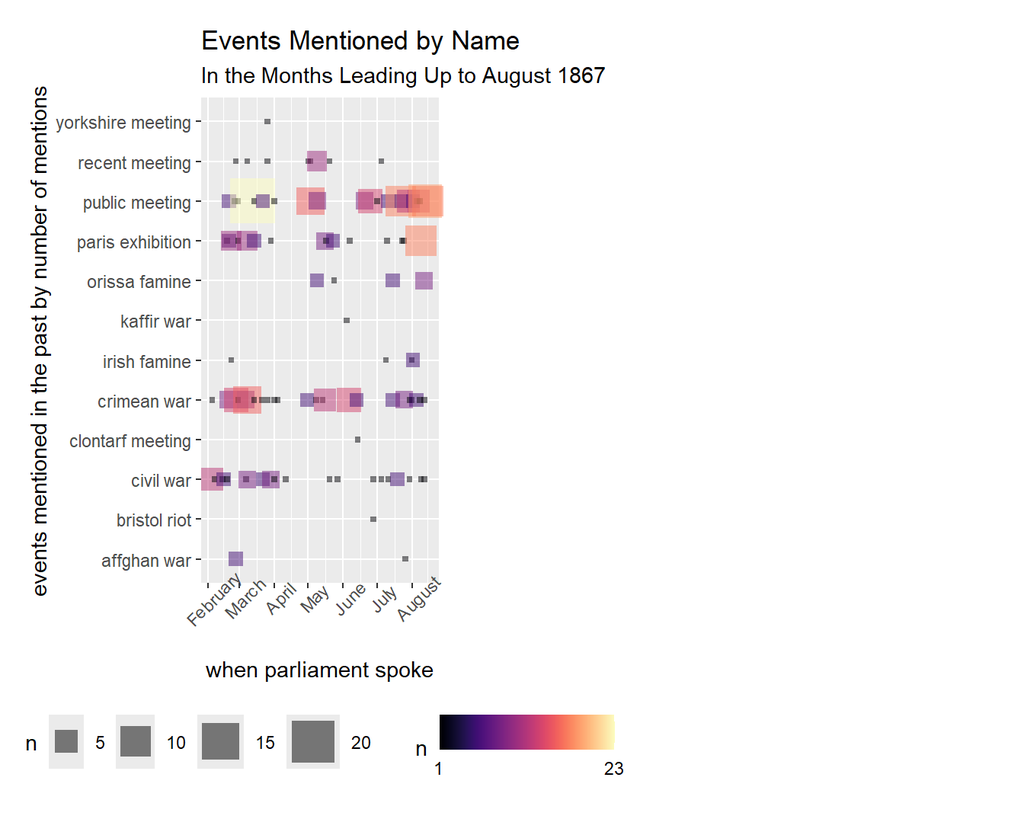

Plot showing the frequency with which Parliament in 1867 referred to major past events—including famines, wars, riots, and public meetings—across the months from February to August. Each square represents a day on which a speech mentioned a given event bigram; larger and brighter squares indicate higher numbers of mentions.

What do we make of this timeline? It suggests a swell of public meetings referenced in parliament in the months leading up to August 1867, which received more intense attention than either the Crimean War or the Paris Exhibition. Individual meetings such as those in Yorkshire or Clontarf received passing acknowledgment rather than deeper debate. Understanding the results of the visualization deeper requires more cycles of research and reading.

One way to approach this line of inquiry would be by using the graph we have generated as a source of concrete questions about how members of parliament invoked current and historical events in the lead-up to the vote on the Second Reform Act. An analyst of history would follow up on most of these questions by reading individual sentences, speeches, and entire debates and to form these readings into a historical argument about the role of events in shaping political reform.

## Finding Historical Events Using a Controlled Vocabulary

Next, let’s return to the idea of finding events using what we have learned about joins. The authors of this book have created a controlled vocabulary of event names which lists the date of famous events like the Magna Carta (1215).

As *The Dangerous Art of Text Mining* makes clear, we understand that there is no universal definition of the most important events in world history. Any controlled vocabulary list has its merits and its omissions. It is in comparing the subtleties of different lists of events that the historian begins to explore the changing political and cultural nature of memory – for example, the fact that references to the Glorious Revolution began to disappear after the First Reform Act, gradually displaced by allusions to the Tudor past.

| event_name | scholar_assigned_date |
| --- | --- |
| french revolution | 1789 |
| magna carta | 1215 |
| norman conquest | 1066 |
| corn laws | 1815 |
| battle of boyne | 1690 |
| glorious revolution | 1688 |

Notice that events contains two columns: events by their name, and the historical dates on which those events occurred.

We will now count events mentioned in parliamentary speeches, starting with using an `inner_join()`. Like its cousin, `left_join()`, `inner_join()` works with two data sets to make a new, combined data set. We use `inner_join()` when we want to analyze shared areas of overlap between two data sets. For our analysis. we want to find the n-grams from `annotated_1830` that are also listed as entities in the events controlled vocabulary.

Notice that the resulting dataset contains speaker and date columns from the parliamentary speeches, but the only bigrams listed are those that correspond to events from `eventslist`.

In the next blocks of code, we use our new list of events to generate a visualization.

| ngram | year | speechdate | scholar_assigned_date | n |
| --- | --- | --- | --- | --- |
| american constitution | 1831 | 1831-10-05 | 1776 | 1 |
| american constitution | 1831 | 1831-10-06 | 1776 | 2 |
| american constitution | 1832 | 1832-04-13 | 1776 | 2 |
| belgian revolution | 1831 | 1831-08-09 | 1830 | 1 |
| belgian revolution | 1831 | 1831-08-18 | 1830 | 1 |
| belgian revolution | 1832 | 1832-03-16 | 1830 | 10 |

| ngram | scholar_assigned_date | total |
| --- | --- | --- |
| norman conquest | 1066 | 5 |
| twelfth century | 1100 | 3 |
| thirteenth century | 1200 | 7 |
| fourteenth century | 1300 | 2 |
| game laws | 1389 | 112 |
| fifteenth century | 1400 | 7 |

| ngram | scholar_assigned_date | total | index | year | speechdate | n |
| --- | --- | --- | --- | --- | --- | --- |
| norman conquest | 1066 | 5 | 41 | 1830 | 1830-11-15 | 1 |
| norman conquest | 1066 | 5 | 41 | 1834 | 1834-03-14 | 1 |
| norman conquest | 1066 | 5 | 41 | 1834 | 1834-04-25 | 1 |
| norman conquest | 1066 | 5 | 41 | 1839 | 1839-07-12 | 2 |
| twelfth century | 1100 | 3 | 43 | 1831 | 1831-07-06 | 1 |
| twelfth century | 1100 | 3 | 43 | 1832 | 1832-02-27 | 1 |

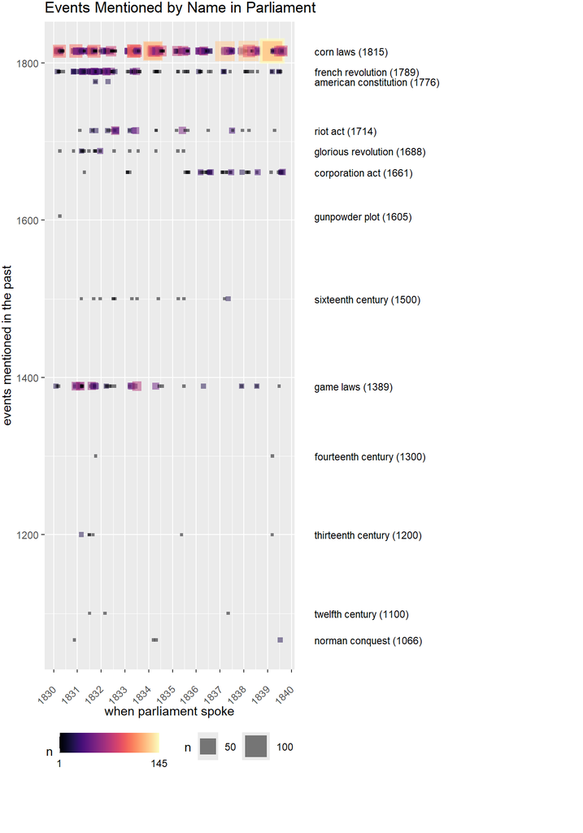

Note that the visualization here resembles the visualization of events we generated above, but in this case, we have some extra information: the actual date of the event mentioned, e.g. 1789 for the French Revolution. We have plotted this historical information on the y-axis. The resulting graph in fact shows two timelines rather than one – a timeline of parliamentary speech on the x-axis and a timeline of historical references on the y-axis.

Why? we find ourselves asking. That verticality of temporal experience–the long perspective on the deep past–seems to be fairly distinct for 1830-32 of all the years in the decade. Why do so many different, varied periods suddenly become relevant all at once? Is this pattern a general characteristic of moments of political reform – that the deep past is trawled for a multitude of examples, for and against?

We continue the explanation through reading.

What we see is a collection of historical references which serve two purposes: one is explaining why the institutions of the past differ from the needs of the present, and one is invoking the fact that parliamentary institutions have changed in the past to support the cause of reform in the present. The arguments work together, not against each other.

While we acknowledge that other historians have studied the discourse of parliamentary reform in detail, and even arrived at this same conclusion, what we find from a data-driven analysis of historical references to past events in parliament is the distinctiveness of 1832 as a moment of memory. Understanding how memory was used requires deep reading and a knowledge of the context of the debates over the vote; but understanding that historical memory was being leveraged in a particularly intensive way in 1832 is an insight that comes from treating text as data.

### Data Processing Order

Throughout this chapter, we worked with large datasets and showed how to handle them effectively The process we demonstrated is especially important when handling a dataste as large the Hansard corpus. For example, if we try to tokenize the entire dataset before narrowing it down, the tokenization steps can exceed our computer’s resources. Instead, by first filtering the dataset to include only the debates we care about–and then tokenizing–we can significantly reduce the processing load.

Here is a typical workflow for handling large data like Hansard:

- Load the Dataset: Import the dataset into your R environment using appropriate functions like `read_csv()`.
- Filter or Subset the Dataset: Narrow down the dataset to include only the data relevant to your analysis. For example, if we are analyzing speeches by William Gladstone, we can filter rows where the speaker is Gladstone using functions like `filter()` from the `dplyr` package. Similarly, we could filter for speeches belonging to a specific debate by filtering the data based on a title. Subsetting early in the process reduces the amount of data that will be processed later, saving processing time and computational resources.
- Clean the Dataset: After subsetting, clean the dataset to prepare it for analysis. Cleaning typically involves handling missing values, removing stop words, and normalizing text (e.g., converting text to lowercase). We can clean data with functions like `mutate()` from `dplyr`, or string processing functions like `str_to_lower()`, which transforms text to lower case, from the `stringr` package.
- Analyze the Dataset: Now that you have just the needed data, perform your analysis by applying metrics.

Although it is poossible clean the entire dataset before narrowing it down, doing so can strain our computer’s processing power or even exceed its available memory. It is often more desirable to filter the dataset first, then clean the smaller, more manageable portion. Following the order: Load -> Subset -> Clean -> Analyze can optimize data processing, which may be especially useful when analyzing change over decades or centuries of data.

# Exercises

## 1) In the code above, we searched for 5-word phrases that reference “the people.” Use the code to find two-word phrases in 1830, 1840, 1850, and 1860 that reference “meeting.” Write a paragraph, quoting at least 10 phrases from each decade. For each of the phrases mentioned more than five times, describe what prejudices, positive or negative, the phrase encapsulates. Use your evidence to answer the question: how did parliamentary references to meetings change between 1830 and 1860?

Tips: Instead of joining every decade together, process the decades separately to avoiding using all your computer’s resources.

| bigram | n |
| --- | --- |
| public meeting | 410 |
| public meetings | 352 |
| meeting held | 106 |
| county meeting | 70 |
| county meetings | 42 |
| meetings held | 42 |
| tithe meetings | 33 |
| respectable meeting | 32 |
| political meetings | 31 |
| tithe meeting | 31 |

[output cut: 70 more lines]

| bigram | n |
| --- | --- |
| public meeting | 272 |
| public meetings | 252 |
| meeting held | 104 |
| repeal meetings | 71 |
| monster meetings | 66 |
| meetings held | 50 |
| repeal meeting | 28 |
| county meeting | 27 |
| clontarf meeting | 25 |
| agricultural meeting | 20 |

[output cut: 70 more lines]

| bigram | n |
| --- | --- |
| public meeting | 248 |
| public meetings | 218 |
| meeting held | 81 |
| meetings held | 33 |
| county meetings | 28 |
| meeting house | 19 |
| recent meeting | 16 |
| monster meetings | 15 |
| county meeting | 13 |
| annual meeting | 12 |

[output cut: 70 more lines]

| bigram | n |
| --- | --- |
| public meetings | 296 |
| public meeting | 256 |
| meeting held | 96 |
| meetings held | 49 |
| recent meeting | 33 |
| county meetings | 28 |
| political meetings | 26 |
| hold meetings | 18 |
| annual meeting | 13 |
| private meeting | 13 |

[output cut: 70 more lines]

#### From the 1830s through the 1860s, parliamentary talk about meetings is consistently dominated by institutional phrases such as “public meeting,” “public meetings,” “meeting held,” “meetings held,” and recurring local governance language like “county meeting” and “county meetings,” suggesting that meetings were a normal part of civil life rather than a rare event.

**In the 1830s**, the most frequent “meeting” bigrams include “public meeting,” “public meetings,” “meeting held,” “county meeting,” “county meetings,” “meetings held,” “tithe meetings,” “tithe meeting,” “respectable meeting,” and “political meetings.” Seeing “respectable meeting” implies an assumption that some gatherings were socially acceptable while others were not, with “tithe meetings” and “political meetings” potentially signalling unrest.

**By the 1840s**, the language shifted toward specific movements and mass mobilization, with frequent phrases like “public meeting,” “public meetings,” “meeting held,” “meetings held,” “repeal meeting,” “repeal meetings,” “monster meetings,” “county meeting,” “clontarf meeting,” and “agricultural meeting.” Strong terms that stood out to me were “monster meetings,” a phrase that frames mass gatherings as threatening or unruly rather than deliberative. These were held to call for the repeal of the British Union in Ireland. We also see “Clontarf meeting,” the last monster meeting and a massive demonstration for Irish self-government which was banned in 1843.

**In the 1850s,** the vocabulary grows more routine and administrative, with “public meeting,” “public meetings,” “meeting held,” “meetings held,” “county meeting,” “county meetings,” “meeting house,” “recent meeting,” “annual meeting,” and even “monster meetings.” Words like “annual meeting,” “recent meeting,” and “meeting house” make meetings sound scheduled and institutional rather than large political events like in the 1840s.

**By the 1860s**, we mainly see “public meetings” alongside more closed-door phrasing such as “recent meeting,”“meeting house,” “annual meeting,” “hold meetings,” “private meeting,” “political meetings,” “county meetings,” “special meeting,” and “general meeting.” This suggests that the discourse evolved from fear of ‘monster’ gatherings to the mundane acceptance of the ‘public meeting’ as a function of the state.

Overall, the evidence suggests that meetings remained a central political tool across decades, but parliamentary language moved from policing legitimacy in “respectable meeting” and stigmatizing mass mobilization in “monster meetings,” toward a more normalized and administrative framing through phrases like “annual meeting,” “recent meeting,” and “hold meetings. The shift in terminology reveals a shift in prejudice: In the 1830s, phrases classified assemblies as either legitimate civic action or dangerous disorder, and by the 1860s, phrases treated meetings as a routine part of formal governance rather than crowds needing control.

## 2) In the code above, we created two kinds of timelines, one for 1867 using a controlled vocabulary of words such as “meeting” and the other for the 1830s using the list of historical events, `eventlist`. Make two more timelines. Apply the controlled vocabulary to the 1830s, and search for the items in `eventlist` in the 1860s. Use the code above to graph the results. Keep in mind that you will need to adjust your controlled vocabulary to what you find in the data.

| bigram | n |
| --- | --- |
| civil war | 508 |
| public meeting | 410 |
| public meetings | 352 |
| war office | 130 |
| american war | 115 |
| meeting held | 106 |
| late war | 76 |
| county meeting | 70 |
| riot act | 59 |
| french war | 45 |

[output cut: 20 more lines]

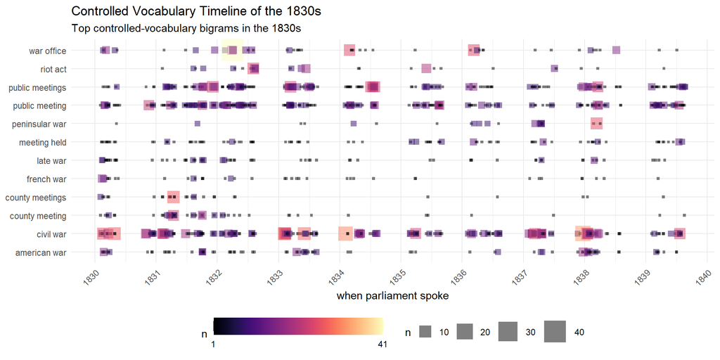

The 1830s timeline shows which controlled-vocabulary bigrams appear most often in parliamentary speech and when they spike, which helps highlight moments when collective concerns became especially prominent. In my results, “meeting” phrases cluster throughout the decade with noticeable bursts in a few years, suggesting periods when organized gatherings were discussed more intensely.

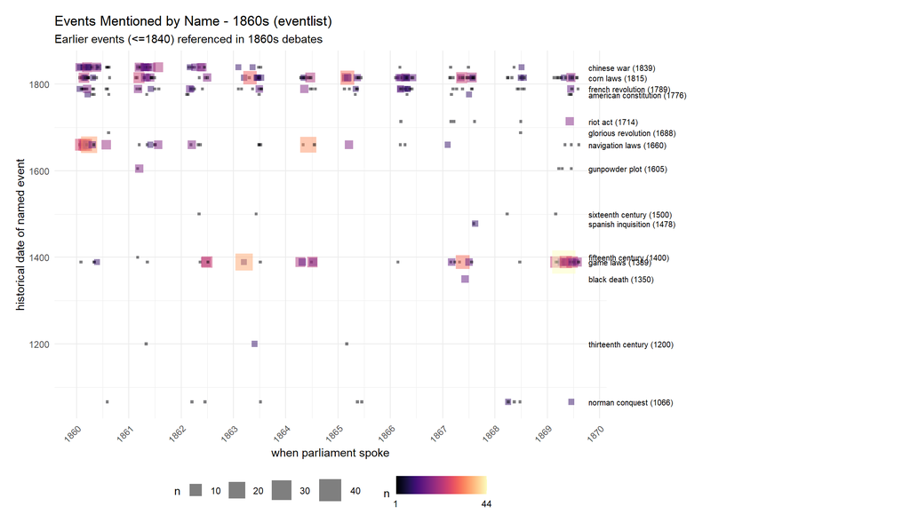

The 1860s plot shows which earlier named events MPs referenced while debating in the 1860s, which suggests what counted as shared historical memory or precedent during later debates.

## 3) Analyze the results of your timelines. Use iterative investigations of phrases, as modeled above, to conduct a distant reading of the parliamentary speeches. Using at least ten examples, compose a one-page essay investigating the question: how did parliamentary speakers use references to contemporary and historical events to make arguments for or against political change?

The Hansard debates of the 19th century did not cite events just to add context, but as evidence and as warning signs. In this exercise, I created two timelines: one for applying a controlled vocabulary of event-related terms to parliamentary speeches from the 1830s, and another to search for historical events before the 1840s referenced during debates in the 1860s. The timelines seem to mirror a shift from managing immediate crisis to curating historical legitimacy - In the 1830s, speakers leaned on phrases tied to public action and public order. In the 1860s, they reached for older events to argue that reform either fit British tradition or threatened it.

In the 1830s controlled-vocabulary timeline, we see a Parliament that was most concerned about mass politics and the threat of disorder. The most frequently appearing phrases are “civil war” (508), “public meeting” (410), and “public meetings” (352), followed by “war office” (130), “american war” (115), with related phrases like “meeting held” (106) and “late war” (76) also appearing often. The constant repetition of “public meetings” and “county meetings” suggests that MPs treated meetings as normal political tools. When a speaker pointed to a public meeting, they could demonstrate that public opinion existed in an organized, legible manner, something Parliament could measure and respond to.

At the same time, legitimacy and order were never without chaos. We also see “riot act” (59), alongside conflict vocabulary such as “French War” (45) and “Peninsular War” (43), suggesting that speakers invoked conflict-heavy language as a warning. A speaker could argue for reform by implying that unrest would grow without change, but another could argue against reform by claiming that change might trigger disorder. Phrases like “war office,” “american war,” “french war,” “peninsular war,” and “late war” pull debates toward questions of national security and governance. In this timeline, these “events” are not neutral references - MPs used crisis language to force urgency and to support arguments for or against change.

In contrast, the 1860s timeline reveals a strategy of historical distance. Rather than focusing on immediate riots and leaning on crisis language, MPs grounded their arguments by mentioning and comparing earlier historical events. Examples of these earlier events (before 1840s) that speakers referenced in the 1860s were “chinese war (1839),” “corn laws (1815),” “french revolution (1789),” “american constitution (1776),” “riot act (1714),” “glorious revolution (1688),” “navigation laws (1660),” “gunpowder plot (1605),” “sixteenth century (1500),” “spanish inquisition (1478),” “fifteenth century (1400),” “game laws (1389),” “black death (1350),” “thirteenth century (1200),” and “norman conquest (1066).” Events such as the “Glorious Revolution (1688)” and the “Navigation Acts” may have been mentioned to symbolize lawful and restorative change, while the French Revolution may be mentioned to warn that political change can slide into violence. Mentioning the Corn Laws offered a more recent “historical” reference point that tied political change to economic policy and social pressure. MPs also sometimes reached further back for dramatic contrasts - with mentions of events from centuries prior like the “gunpowder plot (1605),” the “spanish inquisition (1478),” the “black death (1350),” and the “norman conquest (1066).” These terms serve as extreme historical markers mentioned to caution against instability.

## AI Use Statement

*I used AI tools in the following ways:*

**Tool used:** ChatGPT

**Purpose:** I used AI to help debugged R Markdown issues (kable rendering, missing pipes, joins/anti_join errors) and to verify that my decade-by-decade workflow matched the Chapter 2 methods.

**Example prompts:**

- “My kable table isn’t rendering in HTML/PDF - what’s the smallest fix?”
- “Does my decade-by-decade bigram workflow for ‘meeting’ match Chapter 2’s approach?”

  **Tasks performed independently by me:** I ran and interpreted the Chapter 2 code myself. The final code execution, interpretation of the bigrams, and written arguments are my own. I filtered speeches by decade/year, tokenized into n-grams with `unnest_tokens()`, counted phrase frequencies, and graphed counts over time with `ggplot()`. For timelines, I matched the term lists (controlled vocabulary/eventlist) against the given speeches and summarized event mentions to visualize spikes and shifts.